# Code to reproduce all figures

# Figure 4

## Parsing

The pharmacogenomics dataset analysis. First, let’s parse the data. The required files can be downloaded from:

- Mutations: http://www.cancerrxgene.org/gdsc1000/GDSC1000_WebResources//Data/BEMs/CellLines/CellLines_CG_BEMs.zip (unzip and copy PANCAN_SEQ_BEM.txt)
- CNAs: http://www.cancerrxgene.org/gdsc1000/GDSC1000_WebResources//Data/BEMs/CellLines/CellLines_CNV_BEMs.zip (unzip and copy PANCAN_CNA_BEM.rdata.txt)
- Methylation: http://www.cancerrxgene.org/gdsc1000/GDSC1000_WebResources//Data/preprocessed/methylation/METH_CELL_DATA.txt.zip (unzip and copy F2_METH_CELL_DATA.txt)
- Methylation annotation: http://www.cancerrxgene.org/gdsc1000/GDSC1000_WebResources//Data/otherAnnotations/methSampleId_2_cosmicIds.xlsx (save as B3_METH_CELL_DATA_SampleAnnotations.csv)
- Cancer type / cell line annotation: http://www.cancerrxgene.org/gdsc1000/GDSC1000_WebResources//Data/suppData/TableS1E.xlsx (remove row 1, 2 and 4; remove column 1; and save as sampleDesc.csv)
- Gene expression: http://www.cancerrxgene.org/gdsc1000/GDSC1000_WebResources//Data/preprocessed/Cell_line_RMA_proc_basalExp.txt.zip
- Proteomics: http://tcpaportal.org/mclp/download/MCLP-v1.1-Level4.zip (unzip and rename to prot.tsv)
- IC50s: http://www.cancerrxgene.org/gdsc1000/GDSC1000_WebResources//Data/suppData/TableS4A.xlsx (remove first five rows; remove column 1; and save as ic50.csv)

```r
my.merge = function(x, cell_lines) {
  x = merge(x=cell_lines[,1:2], y=x, by.x="COSMIC.identifier", by.y=0)
  rownames(x) = x$Sample.Name
  x = x[,-(1:2)]
  return(x)
}

read.BEM = function(file, cell_lines, transpose=T, data_type) {
  x = read.delim(file, sep="\t", stringsAsFactors=F, row.names=1)
  if(transpose) {
    x = t(x)
  }
  rownames(x) = gsub("^X", "", rownames(x))
  x = my.merge(x, cell_lines)

  ind = cell_lines[,data_type]=="Y"
  cell_lines_for_datatype = cell_lines$Sample.Name[ind]
  all_zeros = setdiff(cell_lines_for_datatype, rownames(x))
  x[all_zeros,] = 0

  return(x)
}

averageReplicates = function(x, sampleNameCol, exclude) {
  ind = duplicated(x[,sampleNameCol])
  indices = which(ind)
  for(index in indices) {
    ind = which(x[,sampleNameCol]==x[ind,sampleNameCol])
    x[ind[1],-exclude] = colMeans(x[ind,-exclude])
  }
  x = x[-indices,]
  return(x)
}


convert = function(x) {
  new = toupper(gsub("\\.|\\(|\\)|\\-| ","",x))
  return(new)
}

cell_lines = read.csv("data/sampleDesc.csv", stringsAsFactors=F)
rownames(cell_lines) = cell_lines$Sample.Name

mut = read.BEM("data/PANCAN_SEQ_BEM.txt", cell_lines, data_type="Whole.Exome.Sequencing..WES.")
cna = read.BEM("data/PANCAN_CNA_BEM.rdata.txt", cell_lines, transpose=F, data_type="Copy.Number.Alterations..CNA.")

meth = read_tsv("data/F2_METH_CELL_DATA.txt", col_names=T)
meth = as.data.frame(meth)
rownames(meth) = meth[,1]
meth = meth[,-1]
meth = t(meth)
ann = read.delim("data/B3_METH_CELL_DATA_SampleAnnotations.csv", sep=",", header=T, stringsAsFactors=F)
ann$id = paste0(ann$Sentrix_ID, "_", ann$Sentrix_Position)
meth = merge(ann[,c("id","cosmic_id","Sample_Name")], meth, by.x="id", by.y=0)
meth = merge(x=cell_lines[,1:2], y=meth, by.x="COSMIC.identifier", by.y=2)
meth = averageReplicates(meth, "Sample.Name", 1:4)
rownames(meth) = meth$Sample.Name
meth = meth[,-(1:4)]

cancer_type = cell_lines$Cancer.Type..matching.TCGA.label.
names(cancer_type) = cell_lines$Sample.Name
cancer_type[cancer_type=="" | cancer_type=="UNABLE TO CLASSIFY"] = "OTHER"
cancer_type = model.matrix(~cancer_type+0)
colnames(cancer_type) = gsub("^cancer_type","",colnames(cancer_type))
rownames(cancer_type) = cell_lines$Sample.Name

expr = read_tsv("data/Cell_line_RMA_proc_basalExp-1.txt", col_names=T)
expr = as.data.frame(expr)
colnames(expr) = gsub("DATA\\.", "", colnames(expr))
ind = is.na(expr[,1])
expr = expr[!ind,]
rownames(expr) = expr[,1]
expr = expr[,-(1:2)]
expr = t(expr)
expr = my.merge(expr, cell_lines)

ic50 = read.delim("data/ic50.csv", sep=",", header=T, stringsAsFactors=F, row.names=1)

prot = read.delim("data/prot.tsv", sep="\t", stringsAsFactors=F, header=T, row.names=1)
prot = prot[rownames(prot)!="KMH2",] # because we can't determine whether this matches KMH-2 or KM-H2 in GDSC1000
mapping = merge(x=data.frame(prot=rownames(prot), key=convert(rownames(prot))),
                y=data.frame(gdsc=cell_lines$Sample.Name, key=convert(cell_lines$Sample.Name)),
                by.x=2, by.y=2)
prot = prot[as.character(mapping$prot),]
rownames(prot) = mapping$gdsc

data = list()
data$mut = mut
data$cna = cna
data$meth = meth
data$cancer_type = cancer_type
data$expr = expr
data$prot = prot
data$ic50 = ic50
data = lapply(data, as.matrix)
```

## Imputation

For proteomics and IC50 data, the data is imputed as described in the manuscript.

```r
trim.nas = function(x) {
  ind1 = colMeans(is.na(x))<0.3
  ind2 = rowMeans(is.na(x[,ind1]))<0.3
  x = x[ind2,ind1]
  return(x)
}

my.impute = function(x) {
  imputed = impute.svd(x)
  imputed = imputed$x
  rownames(imputed) = rownames(x)
  colnames(imputed) = colnames(x)
  return(imputed)
}

data = intersect.samples(data)
data$prot = trim.nas(data$prot)
data = intersect.samples(data)
data$ic50 = trim.nas(data$ic50)
data = intersect.samples(data)
data$prot = my.impute(data$prot)
data$ic50 = my.impute(data$ic50)
```

## Analysis

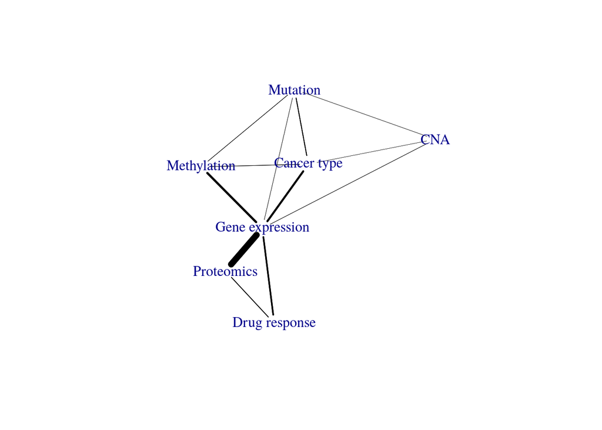

```r
similarity_funs = replicate(length(data), inner.product)
names(similarity_funs) = names(data)
similarity_funs$cna = similarity_funs$cancer_type = similarity_funs$mut = jaccard
config_matrices = compute.config.matrices(data, similarity_funs)
cors = rv.cor.matrix(config_matrices)

set.seed(1)
nperm = nboots = 1000
cors_boot = run.bootstraps(config_matrices, nperm)
cors_perm = run.permutations(config_matrices, nboots)

suffStat = list(cors=cors, cors_perm=cors_perm)
pc.fit = pc(suffStat, indepTest=rv.link.significance, labels=names(data), alpha=0.01, conservative=T, maj.rule=F, solve.confl=T)

min.pcors.per.edge = function(cors, pc.fit) {
  n = nrow(cors)
  pcors = matrix(NA, n, n)
  for(i in 1:n) {
    for(j in 1:n) {
      if(j %in% pc.fit@graph@edgeL[[i]]$edges) {
        res = c()
        count = 1
        set = setdiff(1:nrow(cors), c(i, j))
        for(k in 1:length(set)) {
          sets = combn(set,k)
          for(l in 1:ncol(sets)) {
            res[count] = rv.pcor(cors, i, j, sets[,l])
            count = count+1
          }
        }
        pcors[i,j] = min(res)
      } else {
        pcors[i,j] = 0
      }
    }
  }
  return(pcors)
}

plot.result = function(pcors, seed=NULL) {
  if(!is.null(seed)) {
    set.seed(seed)
  }
  adj_matrix = pcors
  net = graph_from_adjacency_matrix(adj_matrix, weighted=T)
  E(net)$width = E(net)$weight*10
  E(net)$arrow.size = 0
  V(net)$shape = "none"
  plot(net, edge.color="black")
}

pcors = min.pcors.per.edge(cors, pc.fit)
rownames(pcors) = colnames(pcors) = c("Mutation", "CNA", "Methylation", "Cancer type", "Gene expression", "Proteomics", "Drug response")
plot.result(pcors, seed=11)
```

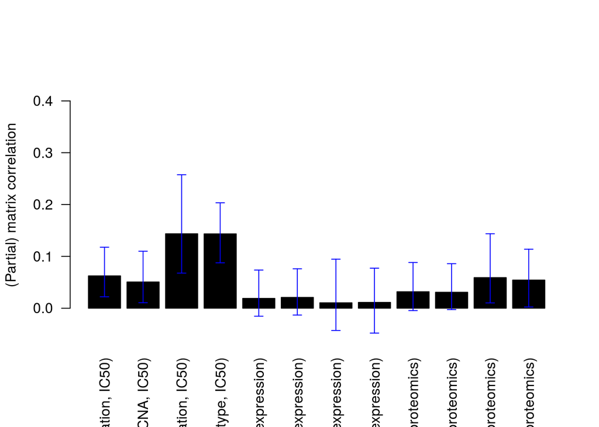

```r
get.statistics = function(cors, cors_perm, cors_boot, a, b, set) {
  rv = rv.pcor(cors, a, b, set)
  conf.int = rv.conf.interval(cors_boot, a, b, set, .99)
  p.value = rv.pval(cors, cors_perm, a, b, set)
  statistics = c(rv, conf.int, p.value)
  names(statistics) = c("RV", "conf.interval.low", "conf.interval.high", "p.value")
  return(statistics)
}

a1 = list()
a1[["RV(mutation, IC50)"]] = get.statistics(cors, cors_perm, cors_boot, "mut","ic50",c())
a1[["RV(CNA, IC50)"]] = get.statistics(cors, cors_perm, cors_boot, "cna","ic50",c())
a1[["RV(methylation, IC50)"]] = get.statistics(cors, cors_perm, cors_boot, "meth","ic50",c())
a1[["RV(cancer type, IC50)"]] = get.statistics(cors, cors_perm, cors_boot, "cancer_type","ic50",c())
a1[["RV(mutation, IC50 | expression)"]] = get.statistics(cors, cors_perm, cors_boot, "mut","ic50","expr")
a1[["RV(CNA, IC50 | expression)"]] = get.statistics(cors, cors_perm, cors_boot, "cna","ic50","expr")
a1[["RV(methylation, IC50 | expression)"]] = get.statistics(cors, cors_perm, cors_boot, "meth","ic50","expr")
a1[["RV(cancer type, IC50 | expression)"]] = get.statistics(cors, cors_perm, cors_boot, "cancer_type","ic50","expr")
a1[["RV(mutation, IC50 | proteomics)"]] = get.statistics(cors, cors_perm, cors_boot, "mut","ic50","prot")
a1[["RV(CNA, IC50 | proteomics)"]] = get.statistics(cors, cors_perm, cors_boot, "cna","ic50","prot")
a1[["RV(methylation, IC50 | proteomics)"]] = get.statistics(cors, cors_perm, cors_boot, "meth","ic50","prot")
a1[["RV(cancer type, IC50 | proteomics)"]] = get.statistics(cors, cors_perm, cors_boot, "cancer_type","ic50","prot")
a1 = do.call(rbind, a1)

a2 = list()
a2[["RV(mutation, proteomics)"]]= get.statistics(cors, cors_perm, cors_boot, "mut","prot",c())
a2[["RV(CNA, proteomics)"]] = get.statistics(cors, cors_perm, cors_boot, "cna","prot",c())
a2[["RV(methylation, proteomics)"]] = get.statistics(cors, cors_perm, cors_boot, "meth","prot",c())
a2[["RV(cancer type, proteomics)"]] = get.statistics(cors, cors_perm, cors_boot, "cancer_type","prot",c())
a2[["RV(mutation, proteomics | expression)"]] = get.statistics(cors, cors_perm, cors_boot, "mut","prot","expr")
a2[["RV(CNA, proteomics | expression)"]] = get.statistics(cors, cors_perm, cors_boot, "cna","prot","expr")
a2[["RV(methylation, proteomics | expression)"]] = get.statistics(cors, cors_perm, cors_boot, "meth","prot","expr")
a2[["RV(cancer type, proteomics | expression)"]] = get.statistics(cors, cors_perm, cors_boot, "cancer_type","prot","expr")
a2 = do.call(rbind, a2)

a3 = list()
a3[["RV(expression, IC50)"]] = get.statistics(cors, cors_perm, cors_boot, "expr","ic50",c())
a3[["RV(proteomics, IC50)"]] = get.statistics(cors, cors_perm, cors_boot, "prot","ic50",c())
a3[["RV(expression, IC50 | proteomics)"]] = get.statistics(cors, cors_perm, cors_boot, "expr","ic50","prot")
a3[["RV(proteomics, IC50 | expression)"]] = get.statistics(cors, cors_perm, cors_boot, "prot","ic50","expr")
a3 = do.call(rbind, a3)

my.barplot = function(a, ylim){
  bp = barplot(a[,1], las=2, ylab="(Partial) matrix correlation", ylim=ylim, col="black")
  arrows(bp, a[,2], bp, a[,3], angle=90, code=3, length=0.05, col="blue")
}

ylim = c(min(a1[,2:3], a2[,2:3], a3[,2:3]), max(a1[,2:3], a2[,2:3], a3[,2:3]))

my.barplot(a1, ylim)
```

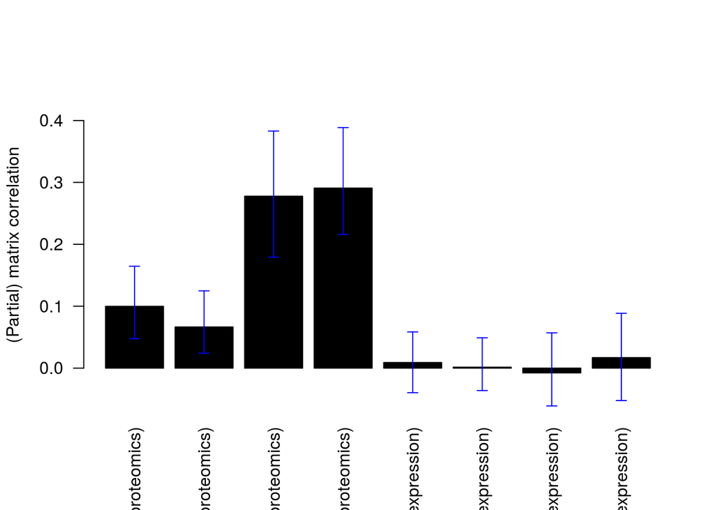

```r
my.barplot(a2, ylim)
```

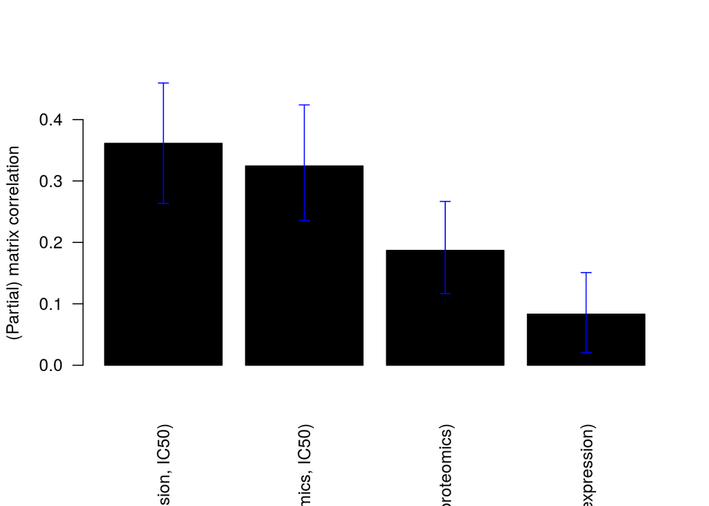

```r
my.barplot(a3, ylim)
```

```r
rv.pcor(cors, "expr","prot",c())
```

```
## [1] 0.757952
```

# Supplementary Figure 1

Is actually a cartoon that is not based on actual data. Hence, there is no code for Supplementary Figure 1.

# Supplementary Figure 2

Drug response prediction analyses. Note that these are more computationally intensive than the rest of analyses. Change the number of cores used according to your machine.

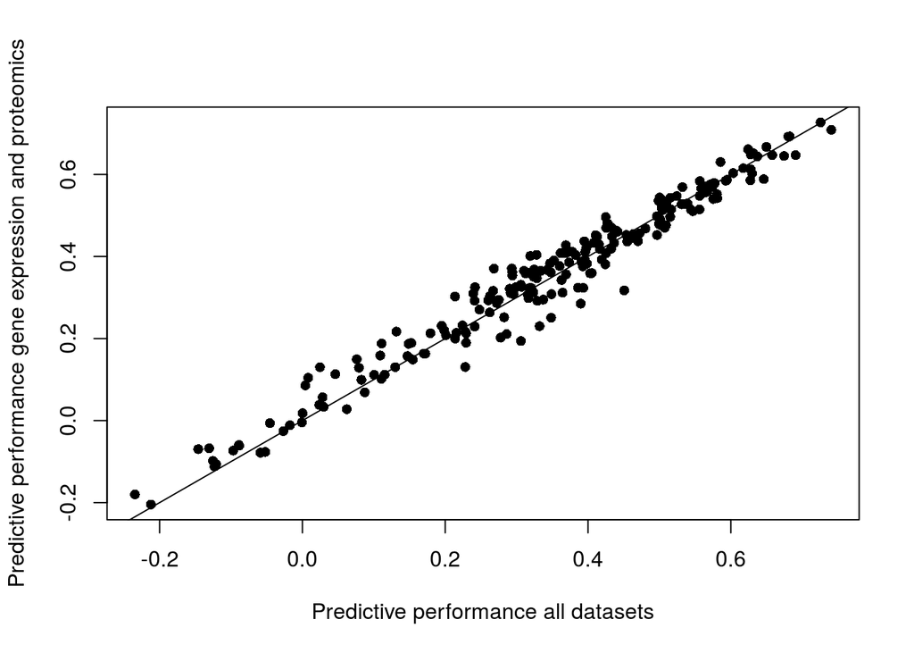

```r
registerDoMC(cores=30)
colnames(data$expr) = paste0(colnames(data$expr),"_expr")
colnames(data$prot) = paste0(colnames(data$prot),"_prot")

x = as.matrix(cbind(data$mut, data$cna, data$meth, data$cancer_type, data$expr, data$prot))
y = data$ic50

x = scale(x, scale=F, center=T)
y = scale(y)

types = c("mut", "cna", "meth", "cancer_type", "expr", "prot")
data_types = c()
for(type in types) {
  data_types = c(data_types, rep(type, ncol(data[[type]])))
}
prot_or_expr = data_types=="prot" | data_types=="expr"

lambda = "lambda.min"
alpha = 0.5

get.perf = function(x, y, method, lambda, alpha, ind=rep(T, ncol(x)), upstream=rep(T, sum(ind))) {
  foreach(i = 1:ncol(y), .combine="c") %dopar% {
    set.seed(1)
    fit = nested.cv(x[,ind], y[,i], upstream, method, alpha=alpha, lambda_glmnet=lambda, lambda_upstream=lambda, lambda_downstream=lambda)
    cor(y[,i], fit$y_hat)
  }
}

perf = list()
perf[["all"]] = get.perf(x, y, "glmnet", lambda, alpha)
perf[["expr+prot"]] = get.perf(x, y, "glmnet", lambda, alpha, ind=prot_or_expr)
perf[["prot_first"]] = get.perf(x, y, "tandem", lambda, alpha, ind=prot_or_expr, upstream=data_types[prot_or_expr]=="prot")
perf[["expr_first"]] = get.perf(x, y, "tandem", lambda, alpha, ind=prot_or_expr, upstream=data_types[prot_or_expr]=="expr")

plot(perf$all, perf$`expr+prot`, pch=16, xlab="Predictive performance all datasets", ylab="Predictive performance gene expression and proteomics")
abline(0,1)
```

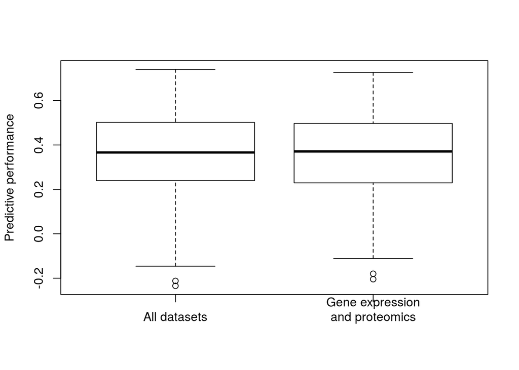

```r
boxplot(perf$all, perf$`expr+prot`, names=c("All datasets", "Gene expression\nand proteomics"), ylab="Predictive performance")
```

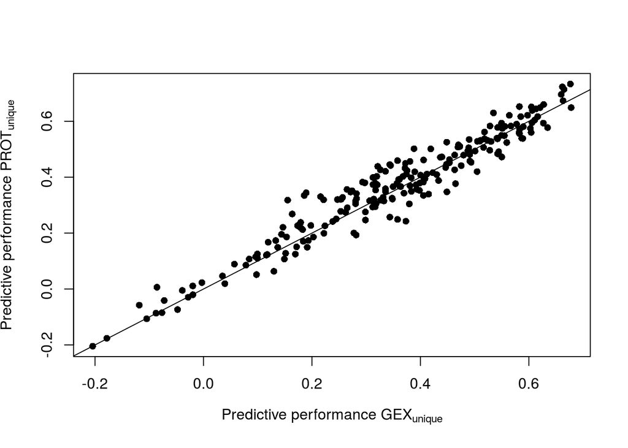

```r
plot(perf$prot_first, perf$expr_first, pch=16, xlab=TeX("Predictive performance $GEX_{unique}$"), ylab=TeX("Predictive performance $PROT_{unique}$"))
abline(0,1)
```

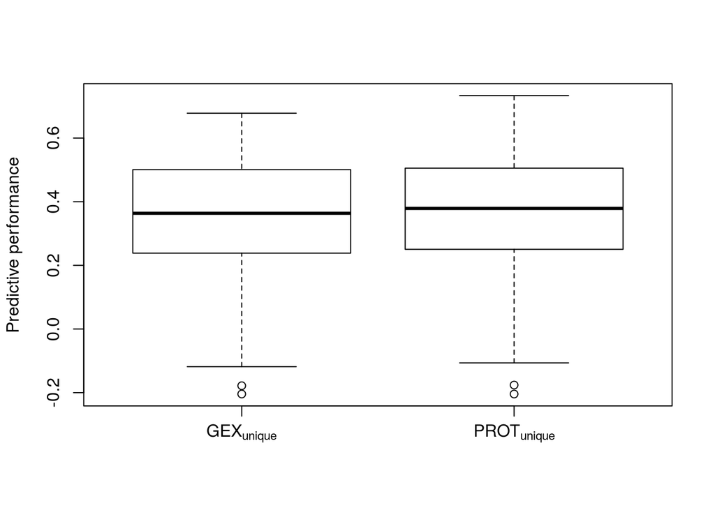

```r
boxplot(perf$prot_first, perf$expr_first, names=c(TeX("$GEX_{unique}$"), TeX("$PROT_{unique}$")), ylab="Predictive performance")
```